# Praca Dodatkowa - poprawa wykresów

Hubert Baniecki

24 05 2019

# 1 Baniecki - boxplot w czasie

## Przed

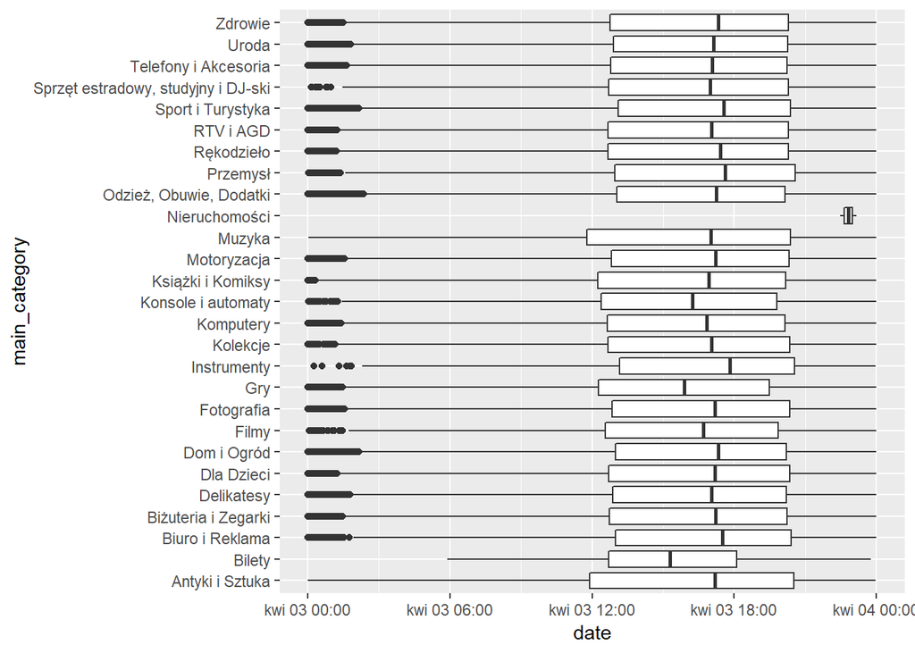

```r
ggplot(allegro, aes(x=main_category, y=date)) + geom_boxplot() + coord_flip()
```

## Po

Oczywiście statystyki z wykresu skrzynkowego nie mają sensu dla zmiennej `date`.  
Wykres ten (jeżeli już) powinien wyglądać mniej więcej tak:

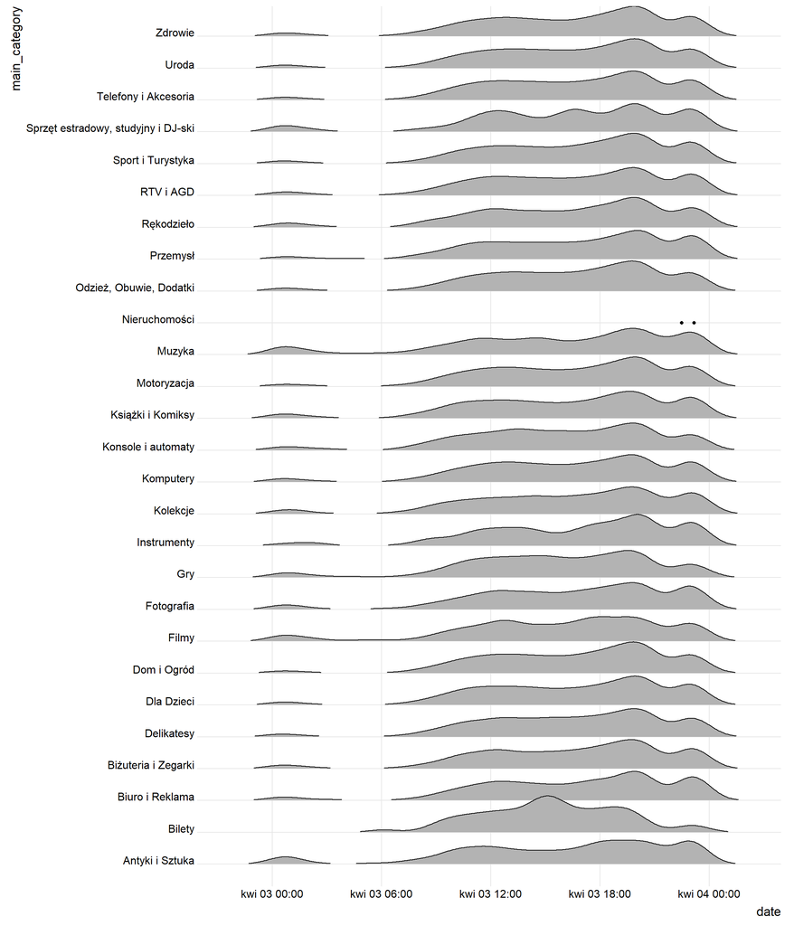

```r
library(ggridges)
ggplot(allegro, aes(x=date, y=main_category)) +
  geom_density_ridges(rel_min_height = 0.02, scale = 1.1)  +
  geom_point(data = allegro[allegro$main_category =="Nieruchomości",], aes(x=date, y=main_category)) +
  theme_ridges()
```

# 2 Rydelek-Merkel-Stawikowski: wykres Chol od thal

## Przed

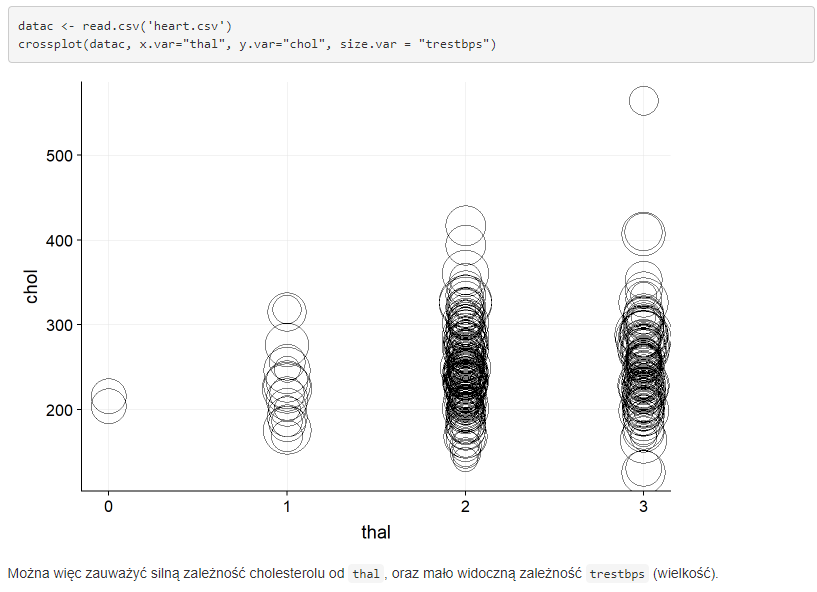

## Po

W opisie zmiennych dla zmiennej `thal` nie ma wartości 0, która występuje tylko dwa razy.  
Można przyjąć, że oznacza ona `NA`. Ponadto cyfra 1 odpowiada 6, 2 odpowiada 3, a 3 odpowiada 7.  
Te kolejne mają swoje praktyczne etykiety.

Jeżeli musi to być na jednym wykresie:

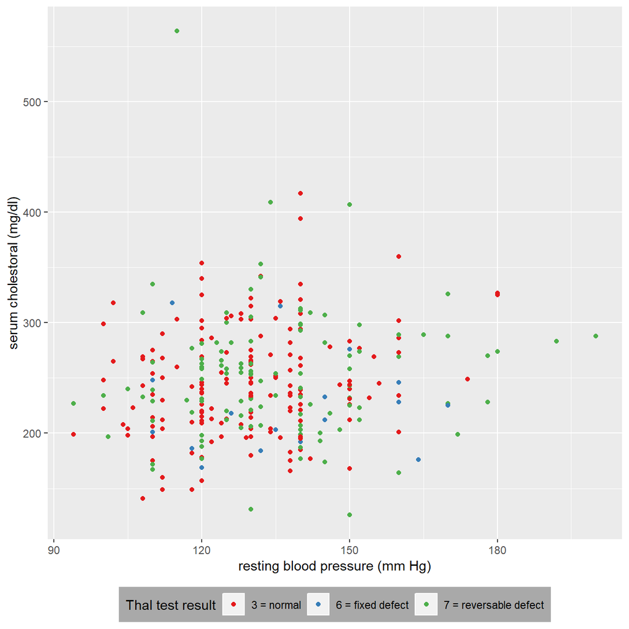

```r
temp <- heart[heart$thal!=0,]
temp$thal <- ifelse(temp$thal==3, 7, ifelse(temp$thal==2, 3, 6))
temp$thal <- as.factor(temp$thal)
ggplot(data = temp) + geom_point(aes(x = trestbps, y = chol, color = thal))  +
  scale_color_brewer(palette="Set1", labels = c("3 = normal", "6 = fixed defect", "7 = reversable defect")) +
  ylab("serum cholestoral (mg/dl)") +
  xlab("resting blood pressure (mm Hg)") +
  labs(color = "Thal test result") +
  theme(legend.background = element_rect(fill = "darkgray"), legend.position = "bottom",)
```

# 3 Boxplot w dyskretnym roku urodzenia / Picasso

## Przed

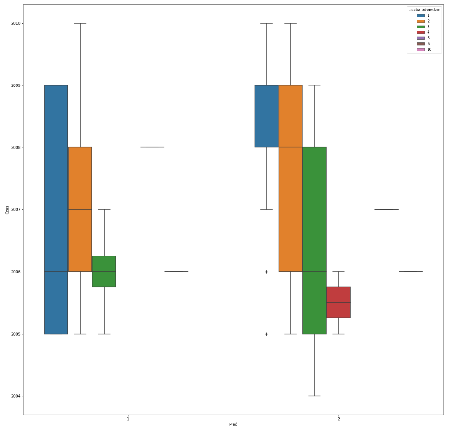

Kompletnie nie wiem co przedstawia ten wykres, ani co autor miał na myśli.  
Spróbuję przedstawić relacje między zmiennymi z wykresu: `czas`, `płeć` i `liczba odwiedzin`.

## Po

Przyjmijmy, że chcemy sprawdzić, jaka jest mediana i moda liczby odwiedzin w grupach docelowych charakteryzujących się zmiennymi `czas` i `płeć`.

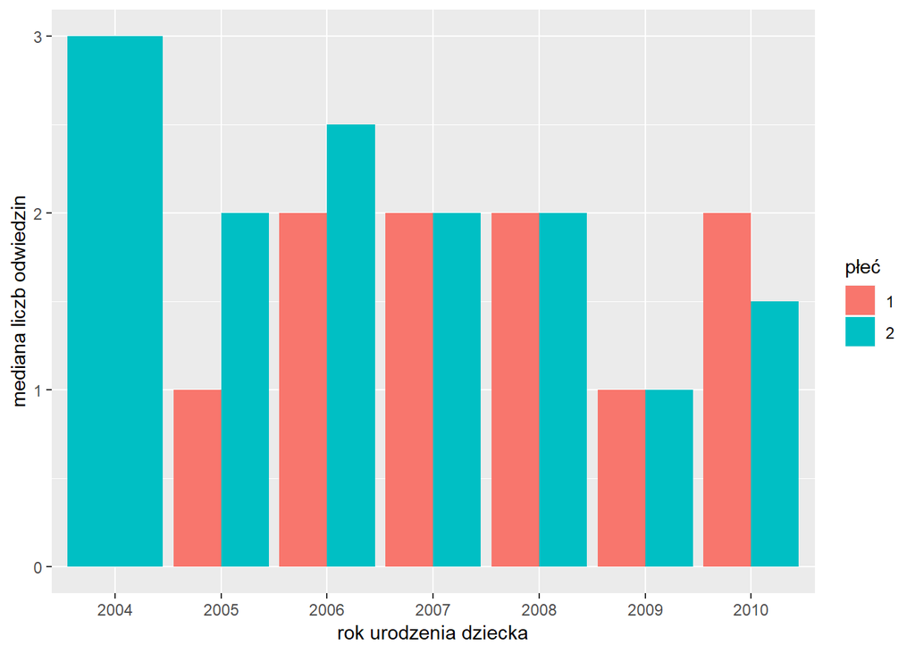

```r
osoby$D1 <- as.factor(osoby$D1)
osoby$D2 <- as.factor(osoby$D2)

Mode <- function(x) {
  ux <- unique(x)
  ux[which.max(tabulate(match(x, ux)))]
}

temp <- osoby %>% group_by(D1,D2) %>% summarise(liczbaOdwiedzinMediana = median(P1),
                                                liczbaOdwiedzinModa = Mode(P1))
ggplot(temp) + geom_col(aes(x = D2, y = liczbaOdwiedzinMediana, fill = D1), position = position_dodge()) +
  xlab("rok urodzenia dziecka") +
  labs(fill = "płeć") +
  ylab("mediana liczb odwiedzin")
```

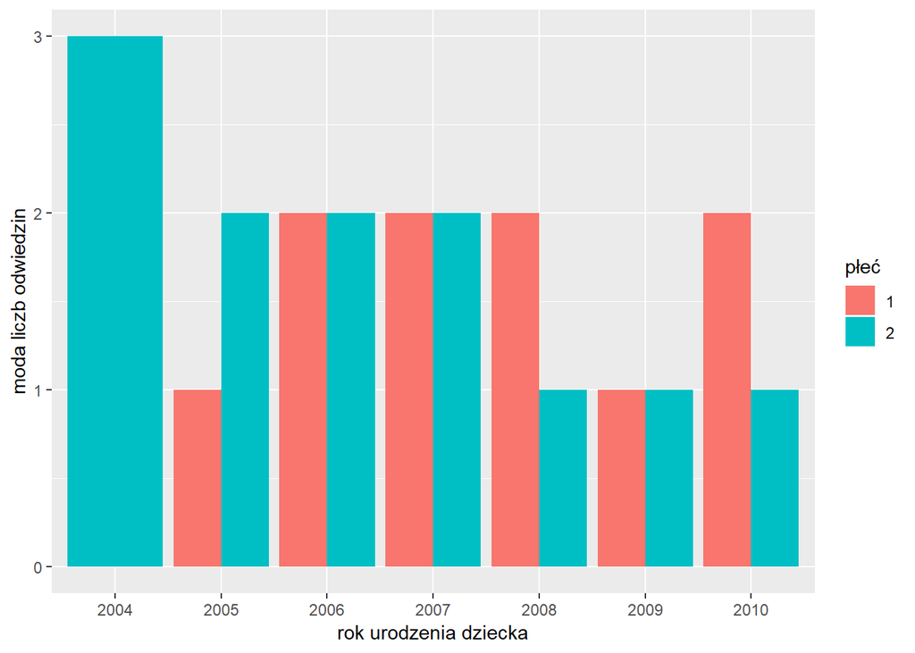

```r
ggplot(temp) + geom_col(aes(x = D2, y = liczbaOdwiedzinModa, fill = D1), position = position_dodge()) +
  xlab("rok urodzenia dziecka") +
  labs(fill = "płeć") +
  ylab("moda liczb odwiedzin")
```

Nie wiem czy z tego wykresu coś wynika.